# Recombination Landscapes in Angiosperms: Results

# 1 Introduction

Meiotic recombination is a crucial mechanism for eukaryotes involved in genome evolution. Because recombination enhances genetic shuffling during the meiosis, it constantly produces new genetic combinations and enhances genetic diversity in populations. Recombination decreases the genetic linkage between loci, hence counteracting interferences between linked loci (the Hill-Robertson interference) and enhancing the efficacy of selection [(Hill & Robertson, 1966)](https://doi.org/10.1017/S0016672300010156). By reducing allelic correlations, the recombination increases genetic variation and efficiently purge deleterious mutations. Meiotic recombination events also imply molecular consequences, with DNA double strands break (DSB) and repair mechanisms of homologous sequences are generally biased toward GC nucleotides in a lot of species ([Galtier et al., 2001](https://www.genetics.org/content/159/2/907.article-info); [Duret & Galtier, 2009](https://doi.org/10.1146/annurev-genom-082908-150001); [Glémin et al., 2015](http://www.genome.org/cgi/doi/10.1101/gr.185488.114); [Rousselle et al., 2019](https://doi.org/10.1093/molbev/msy243)).

[figure not shown]

Figure 1.1: Model of recombination between two homologous strands in red and blue. Double-strand breaks (DSB) can lead to a crossover, with exchange of DNA material between the two paired strands.

Then, reliable estimates of local recombination rates along the genome, also defined as recombination landscapes, are highly relevant in the study of genome evolution, as they may help to understand how species respond to selection and adapt to their environment. Variation in Genome Wide Recombination Rates (GwRR) have been recently reviewed in Eukaryotes, in regard to the many drivers of recombination, from individual to distantly related species levels [(Stapley et al., 2017)](https://doi.org/10.1098/rstb.2016.0455). Yet, this review proved the need for a broad-scale study of the recombination landscapes, i.e. the distribution of the recombination rate within the chromosome. Angiosperms present a high variation of genome architecture, with a 55-fold variation in genome size and 10-fold in number of chromosomes, associated to chromosomal rearrangements (chromosomal inversions, gene duplications). Besides, genomic features such as the local recombination rate, gene density or the nucleotide composition (GC content) vary greatly, and recombination is suspected to directly interact with many genome evolution processes, such as transposable elements (TE) or GC-biased gene conversion (gBGC) ([Gaut et al., 2007](https://doi.org/10.1038/nrg1970)). Although, the study of nucleotide composition is still recent compared to metazoans, especially mammals, and recombination landscapes still need to be explored across the overall Angiosperms taxa. Thus, the comparison of recombination and genomic landscapes is promising in the understanding of patterns of recombination at a large phylogenetic scale for a taxonomic group of high ecological importance.

Based on a comparative genomic approach, we’ll try to assemble a large dataset of Angiosperms’ recombination landscapes to assess the variation of the recombination rate as a function of genome architecture and genomic features. Once published in a public database, these recombination landscapes should be a great advance for the scientific community that would like to test evolutionary hypotheses on a rich broad-scale dataset compared to genomic or ecological data of their own (e.g. life history traits, reproductive system).

Recombination tends to increase the genetic reshuffling and create random combinations of markers from the two parents to the progeny.

What is recombination landscape What is genetic map What is physical map Emphasis on fine-scale structure and hotspots/coldspots, but not so much studies on broad scale patterns along chromosomes

Overview on recombination in Angiosperms Intraspecific variance, e.g. in maize (Bauer et al. 2013) or Brassicacea (Pelé et al. 2017) No recombination driver like PRDM9. Recombination mainly in promoters. Recombination suppression in Angiosperms Termolino et al. (2019)

Bibliographic gap. Many studies on fine-scale (LD, hotspots) or chromosome averaged, but broad scale longitudinal variation along the chromosome poorly studied. Strong need for recombination landscapes, explaining further than Genome-wide Recombination Rates (GwRR) (Stapley et al. 2017) Meta analyses déjà faites, mais ici nouvelle analyse Need to produce data to test theoretical hypotheses (Dapper & Payseur 2017) Although even recent studies conclude on recombination rates with some simple comparisons of cM ~ Mb or cM ~ Marker order without any proper statistical framework to estimate recombination rates (Haenel et al. 2018)

Recombination and genome features/factors of variation. Expected. Empirical monospecific leads. Recombination regulation. Recombination modifiers?

### Hypotheses and design

Recombination is not randomly distributed along the chromosome.

My design is first to estimate and describe the broad-scale landscapes of recombination rate along the chromosome (cM/Mb) in as much species as possible. In order to achieve this, I intend to use the Marey map method described in Rezvoy et al. (2017). It relies on interpolation methods to estimate the local derivatives of the genetic distances (cM) as a function of physical distances (Mb), that is the local recombination rate (cM/Mb).

Find correlations between genome architecture and genomic landscapes (e.g. gene density, GC content). Recombination rate along the chromosome is correlated to chromosome architecture (e.g. chromosome size, centromere position) and some genomic features (e.g. GC content, gene density).

Next to this description of recombination patterns, the further increase in data could lead to explore eco-evolutionary hypotheses, such as the importance of domestication processes in recombination evolution. We will search for pairs of wild/domesticated species to compare, like teosinte and maize. Hypotheses (ref) Projet Maud Tenaillon Intraspecific variation in recombination landscapes can be important (Bauer et al. (2013)).

The variance of recombination between sexes could also be explored with more sex-specific maps allowed by the Marey approach. Hypotheses (ref)

Besides, Population genomic approach with polymorphism data (LD-Hat, LD-Hot)

# 2 Genomic data

All genomic data (genetic map + physical map) comes from the litterature and published supplemental materials. I am gathering genetic maps in any species of Angiosperms, and even some Gymnosperms as outgroup, with special interests to sex-specific maps (sex-averaged maps are good too), wild/domestic species (if possible in the same genus/family), high variance in genome/chomosome sizes (mainly lacking of large genomes), and finally a large representative phylogeny. I began by searching in the litterature for genetic maps, that I found mainly in QTL studies. Keywords were mainly ‘genetic maps’, ‘linkage maps’ associated to ‘high-density’, ‘saturated’ to target best quality maps and finally species names. My main criteria to sort results were species names (species with a well annotated reference genome) and date of publication (first searching the most recent studies for a given species, then going backward in time). In abstracts I searched for a minimum number of markers (> 40 markers per chromosome) to reject low density maps. This rough and naive strategy allowed me to have a broad overview of what species and kind of data are represented in the litterature in a short time, at the very beginning of the PhD, yet it lacked specificity and the number of data effectively recovered per amount of time was low. Then, I focused on more specific searches. In reviews or meta-analysis studying recombination among large phylogenetic groups, I looked for references to genetic maps in Angiosperms (Stapley et al. (2017), Haenel et al. (2018)). All references were saved with metadatas for further analyses (e.g. sex of the map, ploidy level, recombinant inbred lines, chromosome size in Mb and cM, number of markers).

During this extensive bibliographic search I observed that many of these references didn’t published genetic coordinates in supplementary electronic materials (most of them published already made figures). I recovered 385 map references (still increasing), only 75 of them being publicly published, ultimately retaining 28 of them after stringent selection on Marey maps (see below for details).

Actually, I am looking to extend my dataset to a larger panel of maps based on specialists knowledge. Besides the still ongoing litterature search, I moved to a more active search, with the help of Slyvain Glémin. We prospected the network of researchers he knows working on genetic maps. So far, we have many promising answers. The next step will be to contact authors outside of our close network, especially those that didn’t published high-density genetic maps in the references I found, and ask them for their data.

# 3 Estimate recombination landscapes: Marey Maps & Interpolation methods

Meiotic recombination is typically studied through the transmission of polymorphic DNA markers. The design is to examine the patterns of segregation/independence between markers, when two loci are not randomly segregated during meiosis. A higher correlation between two loci (i.e. linkage disequilibrium) demonstrates a higher probability to be transmitted together to the progeny, hence lower recombination between these markers. It has to be noted that there exists two ways of solving a double strand break (DSB), although only resolved crossing over can be observed in genetic data. DSB open a gap in the DNA sequence and pairing between homologous chromosomes. The repair of this gap can lead to a crossing over (CO) or a non-crossing over (NCO), depending on the occurence of a Double Holliday Junction (DHJ) or not. CO results in the exchange of a DNA strand between homologous chromosomes (hence producing a novel haplotype), while NCO are resolved without physical exchange of DNA. Thus, it is clear that only CO can be observed in the distributuon of DNA markers, although some methods allow to estimate NCO with genetic data (Li et al., 2019; Wijnker et al., 2013).

There exist three main methods to estimate the recombination rate with polymorphic DNA markers. - Sperm typing - Pedigree data (crosses) - Polymorphism data and LD-based approaches (Auton and McVean (2007), Stumpf and McVean (2003), Wall and Stevison (2016)) -> huge underlying statistical frameworks (Wang and Rannala (2008)). Historical recombination rate. new developements. e.g. Bayesian framework of Petit et al. 2017 on chromosome CO count directly. Neural network for polymorphism data (Adrion et al. (2019))

For the pedigree approach, the Marey map is the most used method to visualize the distribution of the recombination along the chromosome (Marey map plots, as described below) and estimate the local recombination rate at a broad-scale (1Mb, 100kb in high-density genetic maps) using interpolation methods to fit a curve to the Marey map (Rezvoy et al., 2007). We chose this approach for its advantages, that are sex-specific maps (recombination is known to vary between sexes), accessibility of the data to constitute a large dataset (the method only require a genetic map and a reference genome) and a recombination rate that is not scaled by the effective population size (unlike LD-based approaches). LD-based approaches are more efficient at fine-scale, especially for detecting hotspots/coldspots of recombination. And sperm typing, despite its high resolution, was not appropriate as it is laboratory intensive and restricted to few model organisms.

However, the Marey map approach have some limits. The recombination is observed in a single generation of a small population (hundreds of individuals), hence only a reduced subset of meiotic recombination events are observed, and many putative recombination events are missed. The resolution of the recombination landscape is limited to 100kb in high density genetic maps with a large number of crossings or even 1Mb in lower density genetic maps (ref). Furthermore, few studies tried to evaluate the quality and reliability of interpolation made, and ultimately estimated recombination rate may be biased in many ways, e.g. overfitting, statistical artefacts, biased variance (ref). Uncertainty of estimations is rarely assessed in studies, although final estimates are the product of multiple uncertainties. Marker genotyping, marker mapping, marker anchoring on the reference genome, curve interpolation and finally computing derivatives on this interpolated curve are all introducing errors in the process, that are often not taken in account (ref). Moreover, once the Marey map approach for broad-scale patterns will be set up, I intend to compare recombination landscapes with fine-scale patterns produced with LD-based approahces on polymorphism data.

The origin of the Marey map rationale comes from a method developped by the french scientist Marey and the rail engineer Ibry, whom compared distances in kilometers to distances in time. Chakravarti extended the rationale to genetic data, and expressed genetic distances (cM) as a function to physical distances (Mb) along the chromosome (Chakravarti, 1991).

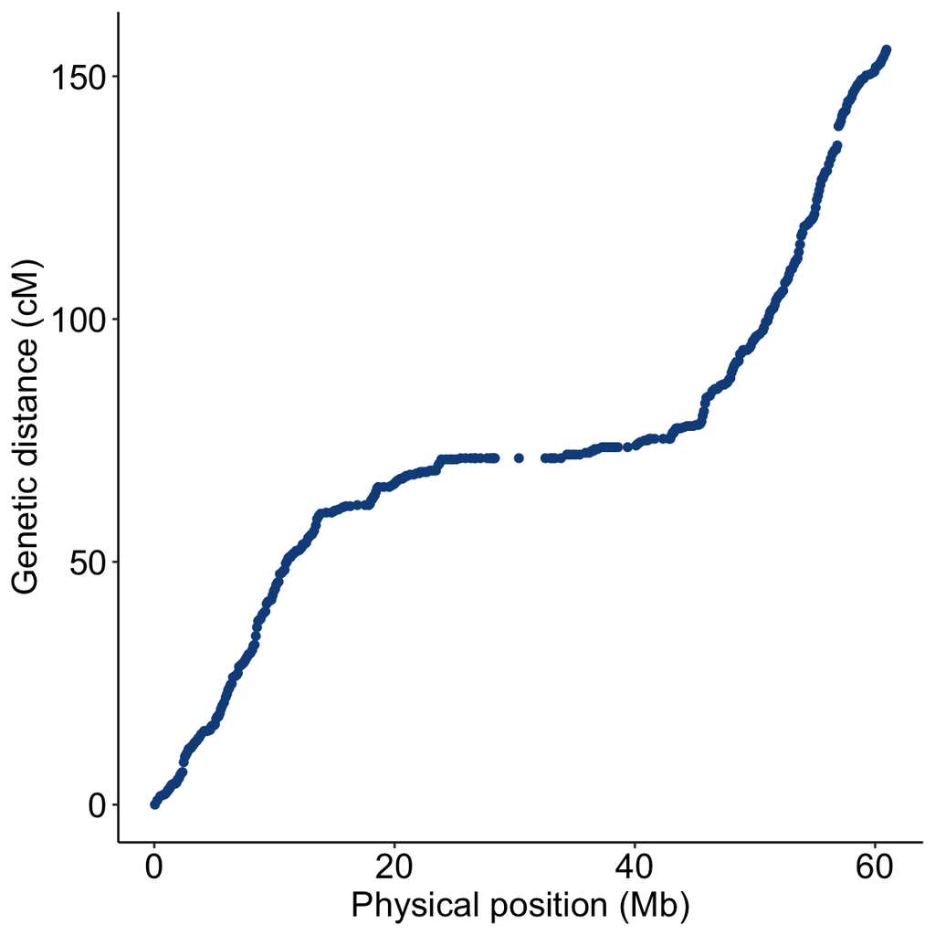

Figure 3.1: Marey map of *Sorghum bicolor* chromosome 10. Genetic function (cM) plotted as a function of the physical distance (Mb).

The idea is that the observed function between genetic and physical distances is not necessarily linear. A linear function would be the uniform model, where the recombination rate is constant along the chromosome. However, when the genetic distance (hence the degree of linkage between two loci) increases for a constant physical distance, there is locally more recombination than expected at random. Inversely, when the genetic distance tends to decrease, there is less recombination than expected (see the figure below). White and Hill developped a conceptual model of Marey maps making the relation between the curvature of the Marey function and the distribution of the recombination along the chromosome (White and Hill, 2020).

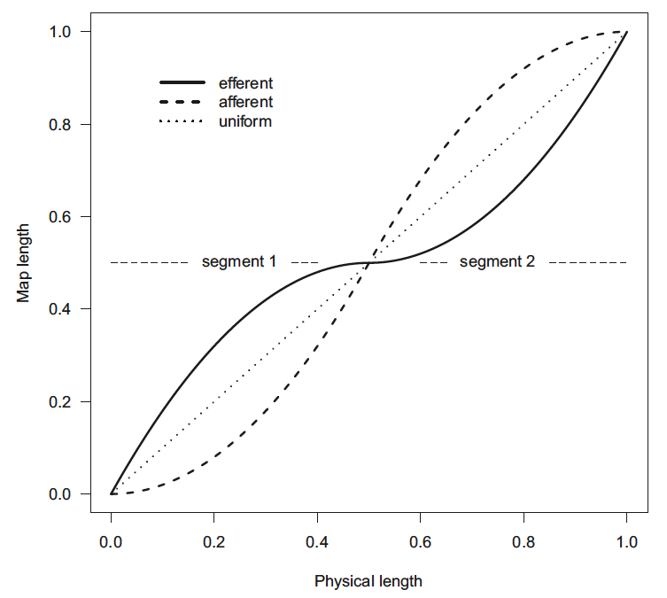

Figure 3.2: Conceptual model of intra-chromosomal recombination heterogeneity proposed by White and Hill (2020). In the uniform model, the recombination rate is constant along the chromosome. Recombination is concentrated in the centre in the afferent model. Recombination is concentrated toward the telomeres in the efferent model.

Basically, the data we need is genetic positions (cM) for one or multiple chromosomes as a function of their physical positions (Mb) along the chromosome. More specifically, we need for the genetic map: (1) Marker name, (2) Chromosome, (3) Genetic distance (with infos about the mapping function used, whether Haldane or Kosambi). For the physical map, we need (1) Marker name, (2) Chromosome, (3) Physical position in Mb (with info on the reference genome used, ideally accession).

However, interpolation methods used to produce recombination maps require some quality criterion. A good genetic map must have at least 40-50 markers per chromosome to produce reliable estimates. Most of markers must follow a monotoneous increasing function when plotting genetic distances as a function of physical distances, that is the guarantee that marker order is congruent between the genetic map and the reference genome. Nonetheless, outliers can be easily removed. Departures from a monotoneous function denotes discrepancies between marker order in genetic and physical maps. Hence, either the genetic or the physical map contain errors in the longitudinal ordering of markers. These incongruences can have strong effects on the interpolation method, increasing the peakiness of the recombination rate variation along the chromosome. Outliers have been removed if they were clearly identified, otherwise, the adjustement of the smoothing function to a stronger smoothing can deal with incongurences while reducing the resolution (landscape is smoother). The function must be increasing, because genetic and physical positions must be anchored in the same direction. Wrong direction on a whole chromosome is easy to correct, yet sometimes only scaffolds have been anchored in the wrong direction, and correction of these shorter segments must be partly manual (manual detection of incorrect segment boundaries).

Finally, to estimate the local recombination rate, a curve is fitted to the Marey map, often through a smoothing function (e.g. Loess regression, smoothing splines). Then, the local derivatives of the fitted curve is an estimation of the local recombination rate.

Basically, fit a function to the data genetic ~ physical distances Estimated by simple linear regression (Ross et al. (2011))

LOESS, does not require to specify a function to fit a model to the data

“After smoothing and forcing monotonicity (Additional file 8), the derivative was calculated to indicate the local value of recombination rate.” Bauer et al. 2013 Figure 3 worth it…

Spline Method, presentation by Berloff et al. (2002)

Colome-Tatche et al. (2012) used a sliding window approach (window size: 3 Mb, step size: 100 kb). “The recombination intensity of each window was calculated by dividing the percentage of recombination events within each window (% of all recombination events) by the percentage of bp covered by the same overlapping marker intervals (%of all marker intervals).”

Comeron et al. (2012) : combined detection of CO and gene conversion events. -> direct observations, classification in CO/GC

Shen et al. (2017) used the LOESS method of Marey map (non-overlapping 1Mb windows)

Silva-Junior and Grattapaglia (2015) “Linkage map-based recombination rates (in cM Mb-1) were estimated for every 5Mb windows using linear regression in R (version 3.1.0) after analyzing the residuals plot against the fitted values to remove outlier markers.”

Apuli et al. (2019) “‘sliding window’ method in MareyMap to estimate recombination rate in windows of 1Mbp, with a step size of 250 kbp and a minimum number of SNP’s per window of 8, in order to avoid regions with large gaps being assigned recombination values.”

Fiston-Lavier et al. (2010) A recombination rate calculator designed for Drosophila, web-based tool “The recombination for any locus is estimated as the derivative of the resulting 3rd order polynomial curve at a given nucleotide coordinate (except for the telomeric and centromeric regions where it is set at zero).” “Alternatively, the genetic position of the markers can be fitted as a function of physical position using a polynomial curve across an entire chromosomal arm. Under this approach, recombination is estimated at an individual nucleotide coordinate as the derivative of the polynomial curve. While the polynomial curve approach is less sensitive to regional variation in recombination rates than the sliding window approach, it is more robust to errors in the physical and genetic maps.”

Doyle et al. (2018) Fitted LOESS, 1Mb windows

Lee and Cox (2010) for Robust Smoothing parameter selection

### Pipeline

Explain the pipeline. What is automated. What will remain manual. Diagram.

Calibrating interpolation parameters.

Many problems faced at this stage of data collection: - only genetic map, no physical map (no reference genome e.g. Amborella) - bad anchors on the reference genome, genetic anchoring on reference genome - no standard DB to retrieve markers, when not specified in the supp. mat.

Table of species that have either a reference genome/a recombination map/both

### Scales

1Mb and 100kb are common scales in recombination studies (ref). The Marey map approach does not permit finer scales, although the resolution is sufficient to explore the broad-scale patterns of chromosome architecture, ranging from 14Mb to 829Mb. We are therefore more interested in chromosome architecture than precise pointwise estimations. Our design is more to describe the whole pattern along the chromosome than to explore correlations at nucleotide or gene level.

A scaled version of the recombination map have been estimated, with the recombination map segmented in 1,000 bins of equal size, in order to comapre maps of different sizes.

### Sensitivity of the method, applied to a set of confident maps (noise added, missing data added…)

Method assessment and validation

Based on data first…

Simulations next…

Power tests

What I want to study for my analyses… Power and sensitivity study of the method

Prospects Not the time for more complex sensitivity analyses, which would require simulation of large genetic sequences (whole chromosomes) of known recombination map, for a large amount of individuals of known pedigree (Slim software). Hence, we could assess the reliability and senstivity of the Marey map method. Yet, we would have to use a mapping function and a genetic mapping algorithm to generate the genetic map and it would be difficult to disentangles effects of genetic map assessment from Marey map interpolation methods. At this time, I found no software able to generate directly a genetic map from known recombination map and physical distances. Many difficulties hard to overcome.

### Recombination landscapes: filtering estimated recombination maps

Question is what is a good and reliable recombination map (errors in genotyping, ordering markers in genetic maps, sequencing whole genomes and finally interpolation methods)? Did it worked properly?

Filtering Marey maps.

Plot good map/bad map

Mapfuser Map orientation require attention as genetic and physical map orientations may be inverted

Colinearity of anchored markers is required -> control quality if both genetic and physical maps are independant

Bauer et al. (2013) used gray lines to represent rec. rates “where the information was missing or not reliable (IBD segments, non-colinearity with B73), and was thus imputed from the other maps”.

Bauer et al. (2013) forced the map to be monotonic “From these physical and genetic positions, we constructed a first Marey map [70] containing all syntenic markers. This Marey map was smoothed using cubic spline interpolations [71], producing a ‘bare’ Marey map that was forced to be monotonic.”

Dewan et al. 2002 “Errors in the order of markers on physical maps can be due to problems with assembly or to incorrect identification of marker positions.” Discuss problems and issues in Marey maps, due to physical or genetic maps Errors mainly due to errors in physical map orders (assembly problems) Markers colinearity

Filtering interpolated recombination maps. Multiple criterion, all redhibitory.

- Mean biased estimates: Departure from the linear relationship between average estimated recombination rate and chromosome wide recombination rate as a criterion of exclusion for chromosomes.

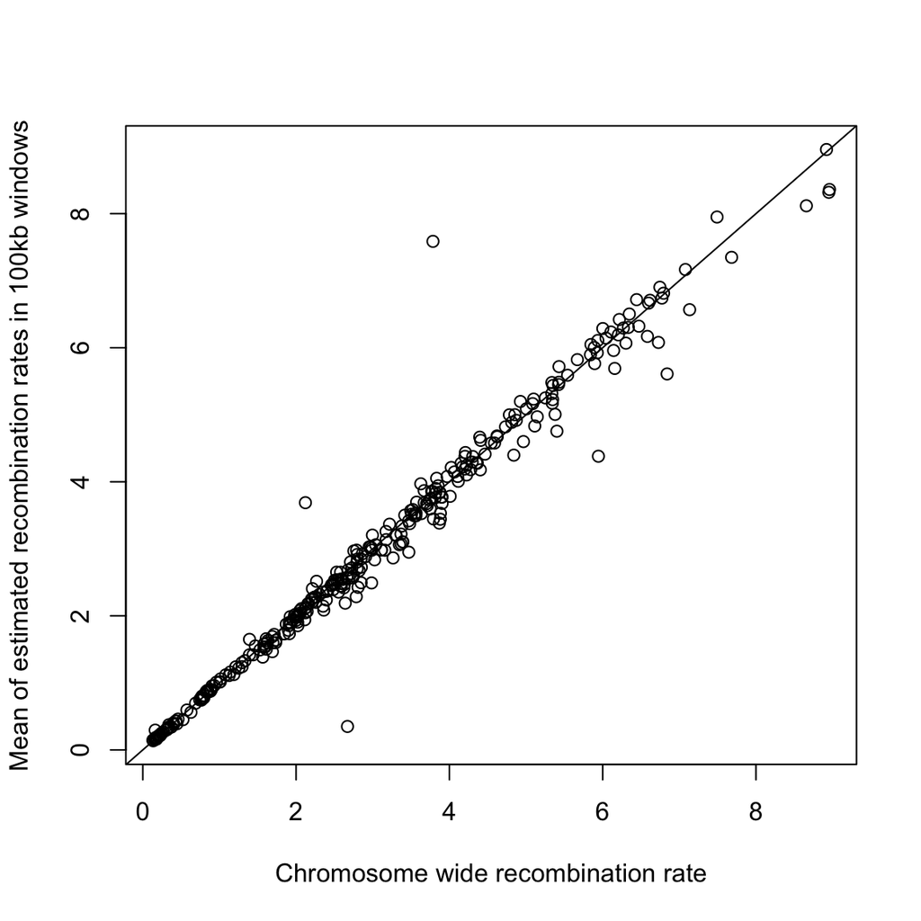

Figure 3.3: Linear relationship between the chromosome wide recombination rate (total genetic length divided by total physical length, cM/Mb) and the mean of recombination rates estimated in 100kb along the chromsome (cM/Mb) used as a cross-validation procedure. Each point represent a chromosome.

- SD biased estimates:
  - Departure from a reasonable range of values (expected from litterature/analytics models)
  - Peak values too high
  - Values much lower than 0
- Overfitting
  - too much peaks (oscillations at lower scales)
- Low power
  - average CI close to sd

List of species retained

Prospects: Genotyping errors + mapping errors + interpolation errors -> multiplication of uncertainty over multiple levels. Working on data estimated, not raw data, hence forgetting to account for uncertainty of first estimates. How did they take care of that? How can we take care of that? once again, simulation and sensitivity analysis could help assess the quality over the complete workflow Bayesian framework from raw data (genotyping) to incorporate errors at every level and propagate uncertainty

### Summary statistics

Scores (summary statistics).

Map quality assessed by genetic map coverage

“ASSESSING GENETIC MAP COVERAGE Method 4 of Chakravarti et al. (1991) was applied to correct for variation in marker density among mammalian genetic maps and we account for undetected crossover events occurring distal to terminal markers using the method of Hall and Willis (2005).” (Dumont & Payseur 2008) Hall and Willis (2005)

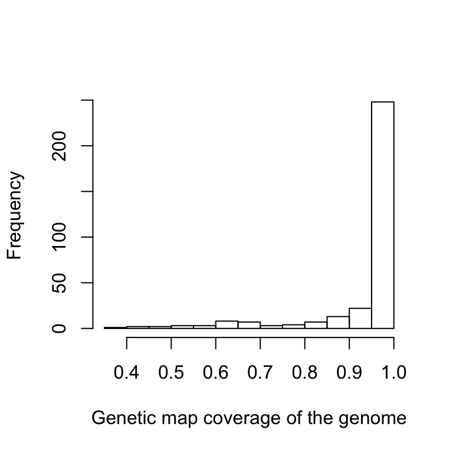

Figure 3.4: Distribution of genetic map coverage in the dataset.

```
## Proportion of maps with a genetic coverage over 95%
```

```
## [1] 0.7678019
```

Most maps have a good genetic coverage (77% have more than 95% coverage).

Phylogenetic tree (reduced to the subset of genetic maps)

Exploratory analyses

As expected, Recombination ~ chromosome size

# 4 Axis one: Recombination is not randomly distributed in the genome

### Recombination is not randomly distributed along the chromosome

Intrachromosomal heterogeneity

Null model by random resampling, Mantel test

Hypothese: clustered vs diffuse architecture

Question is, how to represent structure? Broken stick White and Hill (2020) Visualized as a STRUCTURE plot: barplot of proportions for each chromosome/species Circular phylogeny with barplot in ring Theoretical expectations (neutral, symetric/assymetric, afferent/efferent) A model with three segments seemed sufficient to describe most patterns of recombination rate/most landscapes (broad-scale variation) (White and Hill (2020))

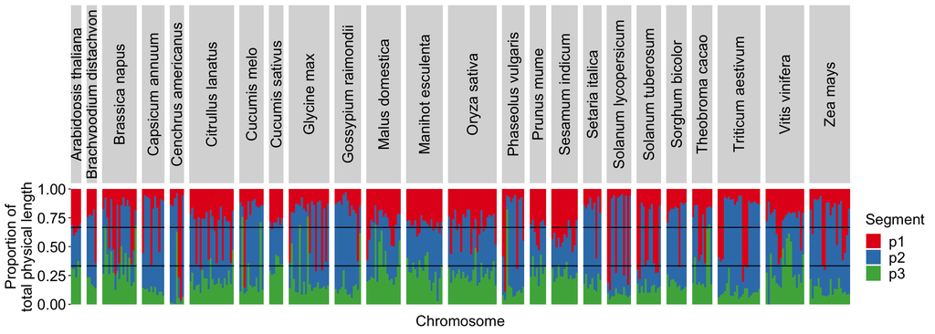

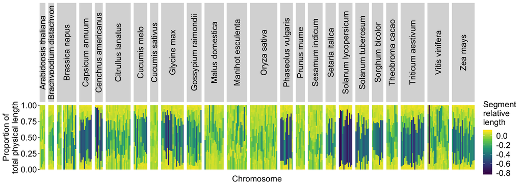

Clustering on segment proportions in k=10

Prospects: Go further than broken stick model in segment decomposition… Sequence compositional complexity Segment regression Another underlying hypothesis, not on segments of equal size (descriptive statistic), but trying to infer the underlying structure from the variance in recombination rate Isochore-like structure? Bernaola-Galvan et al, 2004, “Entropic compositional segmentation (Bernaola-Galvan et al., 1996; Roma´n-Rolda´n et al., 1998) has proven to be a powerful method to partition a DNA sequence into fairly homogeneous, isochore-like segments. We applied here a recently developed segmentation variant which proceeds by maximizing the GC contrast at each step of a recursion.” Segment recombination maps in high/neutral/low recombination regions by algorthimic processes, maximize recombination contrasts, clustering methods Form groups of recombination. “Once a sequence has been segmented, a natural measure of the GC heterogeneity, or complexity, among the segments of a DNA sequence, is the sequence compositional complexity, or SCC (Roma´n-Rolda´n et al., 1998). The SCC of a segmented sequence is the difference between the sequence’s informational (Shannon) entropy and the sum of all its segments’ entropies, weighted by their respective lengths.”

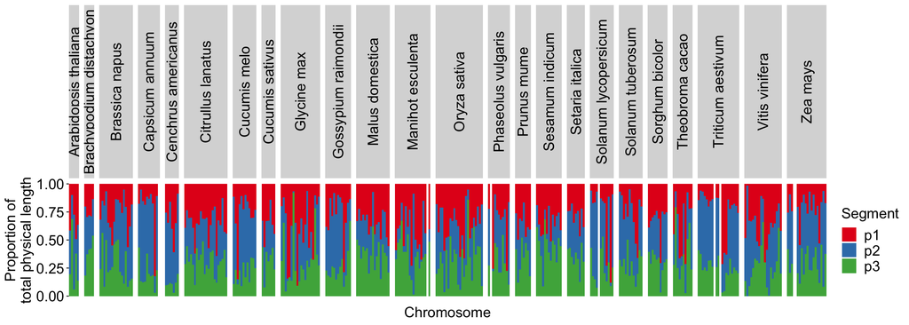

Expand this segment decomposition in maximum entropy searching, for inferring the number of segments k and get segment boundaries (breakpoints) maximizing contrasts between them.

Just at the beginning of this thought…

### Autocorrelation

Autocorrelation tests on different scales (lag = gene distances (except for recombination, due to interpolation scale), 100kb, 1Mb), Mantel test, use of Stochastic Models to test it Correlation of autocorrelation patterns, correlation fo lags in GC/recombination? DFA, detrended fluctuation analysis, “which provides a simple quantitative parameter—the scaling exponent alpha —to represent the correlation properties of a signal”

Compare autocorrelation in both scales Congruent pattern

Table: Maximum Lag in acf() for each chromosome/species Average lag per species

Average autocorrelation between genes in gene distance (see Fig. 2 in Cai et al. 2017)

Consequences of autocorrelation: violation of assumptions, incorrect inferences and misleading results (see Hahn 2006)

If autocorrelation, then use autoregressive (AR) model to take autocorrelation in account (Chakravarthy et al. (2004))

### A probabilistic view of recombination landscapes

White and Hill (2020) Model uniform/afferent/efferent Model BrazierGlemin in Mathematica p(Gamma(a1, b1, z)) + (1-p)(Gamma(a1, b1, L - z)), with L chromosome length Plot in R, with different set of values Theoretical predictions (chromosome length…)

Conceptual models: telomere driven, centromere driven,… How to test hypotheses?

Phenomenological models, that could help describe patterns and disentangles different theoretical models (telomere driven or centromere driven).

### Recombination is not randomly distributed among chromosomes/species - Phylogenetic view

Need more species

Clustering on longitudinal data

AMOVA-like, hierarchical ANOVA chromosome/species levels

ANOVA on longitudinal data -> variance within/between species

Classify/make group of patterns/distributions, DAPC-like

# 5 Axis two: Recombination structure is correlated to genome architecture

### In which way are they heterogeneous/do they vary? Make the link with genome features?

### Recombination rate linked to chromosome size/genome architecture (karyotype, ploidy…)

Hyppothesis: given that at least one recombination event is mandatory at each segregation but that there is few evidences of numerous recombination in a single meiosis (one chiasma per chromosome expected), we can expect that shorter chromosomes wil experience much higher recombination rates than longer chromosomes. Tiley and Burleigh (2015) Already observed in the litterature (ref)

Genome size in bp and pg (C-value)

Mixed-model with species as random factor.

### Gene density

H1: Higher gene density == higher recombination rate

Number of genes Proportion of the window that is CDS/exon Correlation tests

Correlations between gene density and the local recombination rate

Hypothesis: in organisms without PRDM9 or other hotspot driving mechanisms, recombination is majoritarily occuring in gene promoter regions. Hence, higher recombination rates should be related to higher gene densities.

### Do recombination enforce homogeneization of genes instead of the whole genome?

Genetic distances ~ gene distances

H2: Recombination homogeneize genes

Plot genetic distance ~ gene distance (nb of genes) Map of genetic distance as a function of gene distance

Less heterogeneity in recombination~gene distance than in recombination~physical distance

# 6 Axis three: Recombination structure is correlated to genomic features

### Genomic landscapes

Prospects: HMMs Model and correct for autocorrelation Diffusion process (Hahn 2006), Random walk, Hidden Markov model, Spatial Stochastic Processes (Hahn 2006)… Explicitly model the null modle on the data with HMMs (expected distribution) and test significance of specific regions along the chromosome Messer & Arndt (2006) CorGen to generate random null model of autocorrelation

### Correlations between the GC content and the local recombination rate

Hypothesis: gBGC in regions of high recombination increases the local GC content, especially in synonymous mutations (GC3 content, as third codons is often degenerated). large genomes with low recombination rates per base pair are more GC rich (Glémin et al. (2014))

Analysis by quantiles of recombination. Define regions of high or low recombination.

Heatmap + clustering CAH on Rec. rate ~ GC content.

Take care of autocorrelation See Hahn 2006 to estimate the true number of independant observations (eq. 2) Resampling a small subset of points and estimates on resampled distribution, hence reducing autocorrelation by random downsampling (i.i.d. observations) and using the whole information (whole dataset is the pool of information) -> correct because statistic is estimated on uncorrelated data

### Genome rearrangements (i.e. translocations, transposable elements, duplications, inversions) break recombination landscapes

# 7 And next: Estimate recombination with polymorphism data (linkage disequilibrium in populations)

Coalescence based methods. Evaluate all past meioses in the genealogy (practically all meioses can be observed) Population-scaled recombination rate rho = 4*Ne*r where Ne is effective population size and r the map of sex-averaged recombination rate

LD based Methods - Wild Mouse in Booker et al. (2017) - Medicago truncatulata Paape et al. (2012) -> fine method, very detailed, LDhat for recombination rate and sequenceLDhot for hotspots

Machine Learning is the new big improvement of methods Adrion et al. 2019 Gao et al. 2016 Lin et al. 2013

This future development could be part of the third axis, to understand a more integrative view of genomic correlations with recombination, from broad-scale to fine scale (1Mb to few kb).

Besides, population genomic dimension…

# References

Adrion, J.R., Galloway, J.G., Kern, A.D., 2019. Inferring the landscape of recombination using recurrent neural networks (Preprint). Evolutionary Biology.

Apuli, R.-P., Bernhardsson, C., Schiffthaler, B., Robinson, K.M., Jansson, S., Street, N.R., Ingvarsson, P.K., 2019. Constructing a high-density linkage map to infer the genomic landscape of recombination rate variation in European Aspen *(**Populus* *Tremula)* (Preprint). Evolutionary Biology.

Auton, A., McVean, G., 2007. Recombination rate estimation in the presence of hotspots. Genome Research 17, 1219–1227.

Bauer, E., Falque, M., Walter, H., Bauland, C., Camisan, C., Campo, L., Meyer, N., Ranc, N., Rincent, R., Schipprack, W., Altmann, T., Flament, P., Melchinger, A.E., Menz, M., Moreno-González, J., Ouzunova, M., Revilla, P., Charcosset, A., Martin, O.C., Schön, C.-C., 2013. Intraspecific variation of recombination rate in maize. Genome Biology 14, R103.

Booker, T.R., Ness, R.W., Keightley, P.D., 2017. The Recombination Landscape in Wild House Mice Inferred Using Population Genomic Data. Genetics 207, 297–309.

Chakravarthy, N., Spanias, A., Iasemidis, L.D., Tsakalis, K., 2004. Autoregressive Modeling and Feature Analysis of DNA Sequences. EURASIP Journal on Advances in Signal Processing 2004, 952689.

Chakravarti, A., 1991. A graphical representation of genetic and physical maps: The Marey map. Genomics 11, 219–222.

Colome-Tatche, M., Cortijo, S., Wardenaar, R., Morgado, L., Lahouze, B., Sarazin, A., Etcheverry, M., Martin, A., Feng, S., Duvernois-Berthet, E., Labadie, K., Wincker, P., Jacobsen, S.E., Jansen, R.C., Colot, V., Johannes, F., 2012. Features of the Arabidopsis recombination landscape resulting from the combined loss of sequence variation and DNA methylation. Proceedings of the National Academy of Sciences 109, 16240–16245.

Comeron, J.M., Ratnappan, R., Bailin, S., 2012. The Many Landscapes of Recombination in Drosophila melanogaster. PLoS Genetics 8, e1002905.

Doyle, S.R., Laing, R., Bartley, D.J., Britton, C., Chaudhry, U., Gilleard, J.S., Holroyd, N., Mable, B.K., Maitland, K., Morrison, A.A., Tait, A., Tracey, A., Berriman, M., Devaney, E., Cotton, J.A., Sargison, N.D., 2018. A Genome Resequencing-Based Genetic Map Reveals the Recombination Landscape of an Outbred Parasitic Nematode in the Presence of Polyploidy and Polyandry. Genome Biology and Evolution 10, 396–409.

Fiston-Lavier, A.-S., Singh, N.D., Lipatov, M., Petrov, D.A., 2010. Drosophila melanogaster recombination rate calculator. Gene 463, 18–20.

Glémin, S., Clément, Y., David, J., Ressayre, A., 2014. GC content evolution in coding regions of angiosperm genomes: A unifying hypothesis. Trends in Genetics 30, 263–270.

Haenel, Q., Laurentino, T.G., Roesti, M., Berner, D., 2018. Meta-analysis of chromosome-scale crossover rate variation in eukaryotes and its significance to evolutionary genomics. Molecular Ecology 27, 2477–2497.

Hall, M.C., Willis, J.H., 2005. Transmission Ratio Distortion in Intraspecific Hybrids of *Mimulus* *Guttatus*: Implications for Genomic Divergence. Genetics 170, 375–386.

Lee, J.S., Cox, D.D., 2010. Robust smoothing: Smoothing parameter selection and applications to fluorescence spectroscopy. Computational Statistics & Data Analysis 54, 3131–3143.

Li, R., Bitoun, E., Altemose, N., Davies, R.W., Davies, B., Myers, S.R., 2019. A high-resolution map of non-crossover events reveals impacts of genetic diversity on mammalian meiotic recombination. Nature Communications 10, 3900.

Martin, D.M., Bryan, G., 2016. DMAP representation of physical and genetic map correlation (Preprint). Bioinformatics.

Paape, T., Zhou, P., Branca, A., Briskine, R., Young, N., Tiffin, P., 2012. Fine-Scale Population Recombination Rates, Hotspots, and Correlates of Recombination in the Medicago truncatula Genome. Genome Biology and Evolution 4, 726–737.

Rezvoy, C., Charif, D., Gueguen, L., Marais, G.A., 2007. MareyMap: An R-based tool with graphical interface for estimating recombination rates. Bioinformatics 23, 2188–2189.

Ross, J.A., Koboldt, D.C., Staisch, J.E., Chamberlin, H.M., Gupta, B.P., Miller, R.D., Baird, S.E., Haag, E.S., 2011. Caenorhabditis briggsae Recombinant Inbred Line Genotypes Reveal Inter-Strain Incompatibility and the Evolution of Recombination. PLoS Genetics 7, e1002174.

Shen, C., Li, X., Zhang, R., Lin, Z., 2017. Genome-wide recombination rate variation in a recombination map of cotton. PLOS ONE 12, e0188682.

Siberchicot, A., Bessy, A., Guéguen, L., Marais, G.A., 2017. MareyMap Online: A User-Friendly Web Application and Database Service for Estimating Recombination Rates Using Physical and Genetic Maps. Genome Biology and Evolution 9, 2506–2509.

Siberchicot, A., Rezvoy, C., Charif, D., Gueguen, L., Marais, G., n.d. The MareyMap package version 1.3 10.

Silva-Junior, O.B., Grattapaglia, D., 2015. Genome-wide patterns of recombination, linkage disequilibrium and nucleotide diversity from pooled resequencing and single nucleotide polymorphism genotyping unlock the evolutionary history of *Eucalyptus* *Grandis*. New Phytologist 208, 830–845.

Stapley, J., Feulner, P.G.D., Johnston, S.E., Santure, A.W., Smadja, C.M., 2017. Variation in recombination frequency and distribution across eukaryotes: Patterns and processes. Philosophical Transactions of the Royal Society B: Biological Sciences 372, 20160455.

Stumpf, M.P.H., McVean, G.A.T., 2003. Estimating recombination rates from population-genetic data. Nature Reviews Genetics 4, 959–968.

Termolino, P., Falque, M., Aiese Cigliano, R., Cremona, G., Paparo, R., Ederveen, A., Martin, O.C., Consiglio, F.M., Conicella, C., 2019. Recombination suppression in heterozygotes for a pericentric inversion induces the interchromosomal effect on crossovers in Arabidopsis. The Plant Journal 100, 1163–1175.

Tiley, G.P., Burleigh, J.G., 2015. The relationship of recombination rate, genome structure, and patterns of molecular evolution across angiosperms. BMC Evolutionary Biology 15, 194.

van Muijen, D., Basnet, R.K., Dek, N.N., Maliepaard, C., Gutteling, E.W., 2017. Mapfuser: An integrative toolbox for consensus map construction and Marey maps (Preprint). Genetics.

Wang, Y., Rannala, B., 2008. Bayesian inference of fine-scale recombination rates using population genomic data. Philosophical Transactions of the Royal Society B: Biological Sciences 363, 3921–3930.

White, I.M.S., Hill, W.G., 2020. Effect of heterogeneity in recombination rate on variation in realised relationship. Heredity 124, 28–36.

Wijnker, E., Velikkakam James, G., Ding, J., Becker, F., Klasen, J.R., Rawat, V., Rowan, B.A., de Jong, D.F., de Snoo, C.B., Zapata, L., Huettel, B., de Jong, H., Ossowski, S., Weigel, D., Koornneef, M., Keurentjes, J.J., Schneeberger, K., 2013. The genomic landscape of meiotic crossovers and gene conversions in Arabidopsis thaliana. eLife 2, e01426.